# iris_visualization

## Visualization - Iris flower data set

Base source: [w3resource Scikit-learn exercise](https://www.w3resource.com/machine-learning/scikit-learn/iris/index.php)

```python
#Import section
import numpy as np
import pandas as pd
import matplotlib.pyplot as plt
import seaborn as sns
sns.set()
```

1. Write a Python program to create a plot to get a general Statistics of Iris data.

```python
iris = pd.read_csv('iris.csv').drop('Id', axis=1)
iris.head(2)
```

|  | SepalLengthCm | SepalWidthCm | PetalLengthCm | PetalWidthCm | Species |
| --- | --- | --- | --- | --- | --- |
| 0 | 5.1 | 3.5 | 1.4 | 0.2 | Iris-setosa |
| 1 | 4.9 | 3.0 | 1.4 | 0.2 | Iris-setosa |

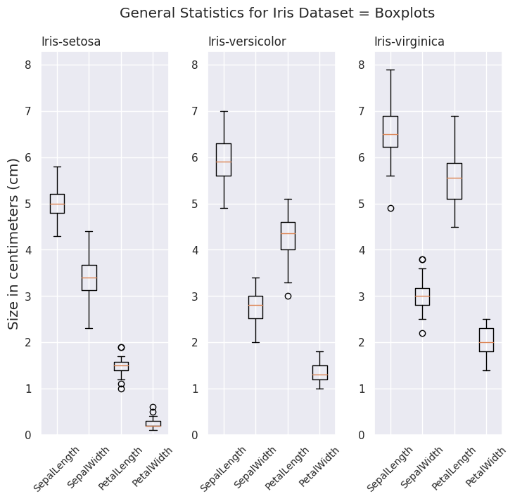

```python
#The exercise solution appears broken, so mine took a totally different path.
figure, axis = plt.subplots(1, 3, figsize=(8, 7))
for n, species in enumerate(iris['Species'].unique()):
    df = iris[iris['Species'] == species]
    axis[n].boxplot([df[col] for col in iris.columns[:-1]])
    axis[n].set_title(species, loc='left')
    axis[n].set_xlim(0.5, len(iris.columns[:-1]) + 0.5)
    axis[n].set_ylim(0.0, iris[iris.columns[:-1]].max().max() * 1.05)
    axis[n].set_xticklabels([col[:-2] for col in iris.columns[:-1]],rotation=45, fontsize=10)
figure.suptitle("General Statistics for Iris Dataset = Boxplots")
figure.supylabel("Size in centimeters (cm)")
plt.subplots_adjust(top=0.89, wspace=0.3, left=0.08)
plt.show()
```

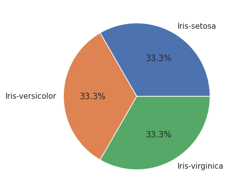

```python
plt.pie(iris['Species'].value_counts().values,
        labels=iris['Species'].unique(),
        autopct='%1.1f%%')
plt.show()
```

4. Write a Python program to create a graph to find relationship between the sepal length and width.

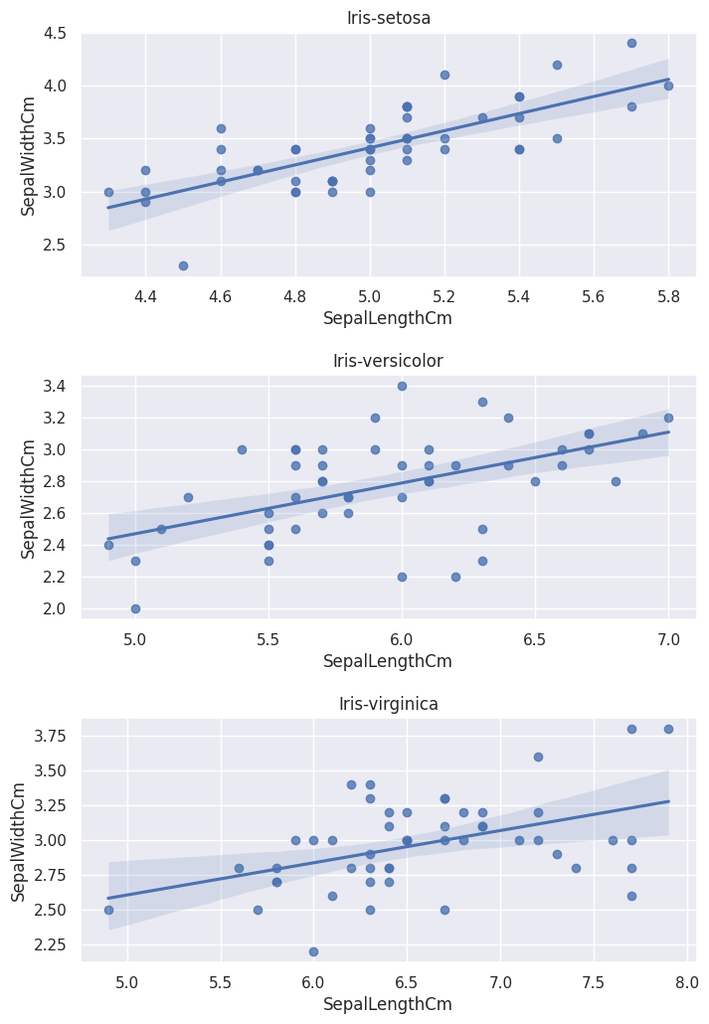

```python
fig_reg, axes = plt.subplots(3, figsize=(8, 12))
for n, species in enumerate(iris['Species'].unique()):
    sns.regplot(data=iris[iris['Species'] == species], x='SepalLengthCm', y='SepalWidthCm', ax=axes[n])
    axes[n].set_title(species)
plt.subplots_adjust(top=0.89, hspace=0.4)
plt.show()
```

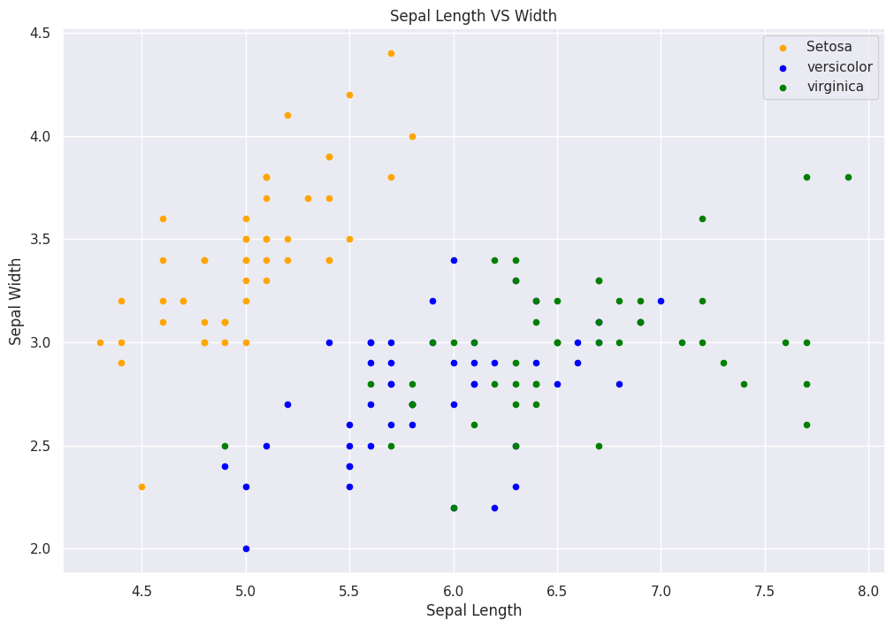

```python
#Exercise solution
fig = iris[iris.Species=='Iris-setosa'].plot(kind='scatter',x='SepalLengthCm',y='SepalWidthCm',color='orange', label='Setosa')
iris[iris.Species=='Iris-versicolor'].plot(kind='scatter',x='SepalLengthCm',y='SepalWidthCm',color='blue', label='versicolor',ax=fig)
iris[iris.Species=='Iris-virginica'].plot(kind='scatter',x='SepalLengthCm',y='SepalWidthCm',color='green', label='virginica', ax=fig)
fig.set_xlabel("Sepal Length")
fig.set_ylabel("Sepal Width")
fig.set_title("Sepal Length VS Width")
fig=plt.gcf()
fig.set_size_inches(12,8)
plt.show()
```

5. Write a Python program to create a graph to find relationship between the petal length and width.

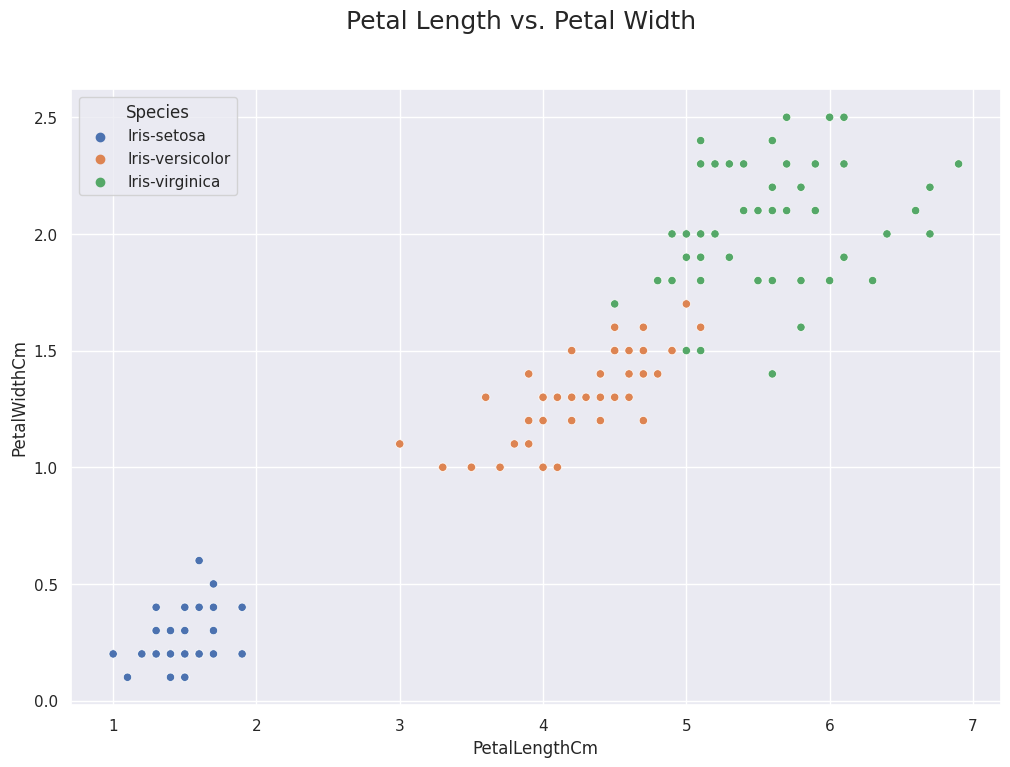

```python
x = 'PetalLengthCm'
y = 'PetalWidthCm'
fig, axis = plt.subplots(figsize=(12, 8))
sns.scatterplot(iris, x=x, y=y, hue='Species', ax=axis)
fig.suptitle("Petal Length vs. Petal Width", fontsize=18)
plt.show()
```

6. Write a Python program to create a graph to see how the length and width of SepalLength, SepalWidth, PetalLength, PetalWidth are distributed.

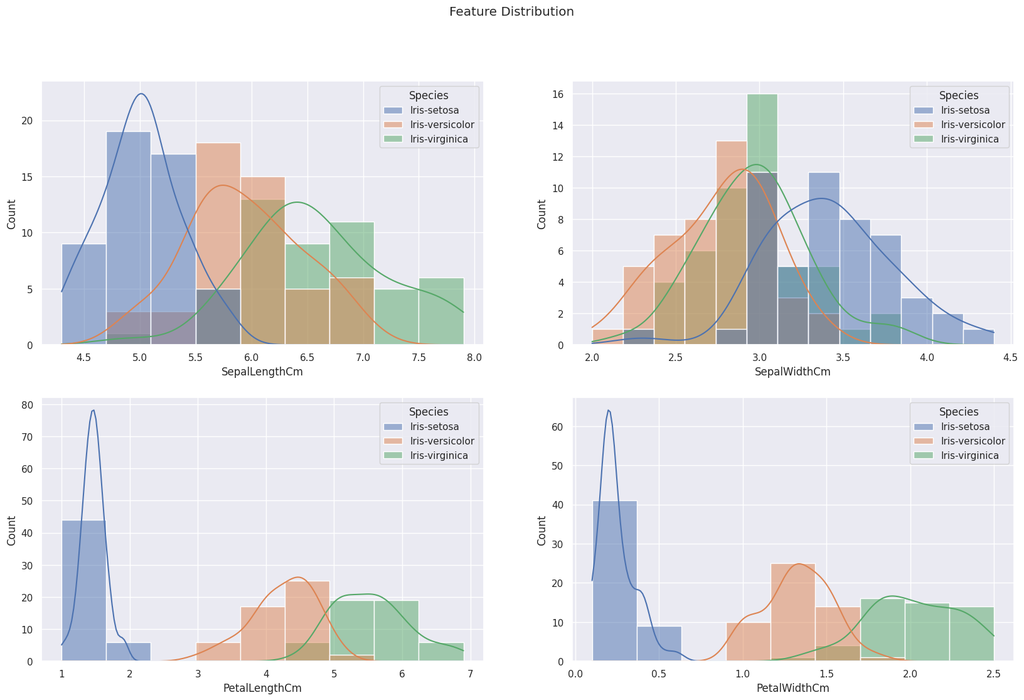

```python
fig, axes = plt.subplots(2, 2, figsize=(20, 12))
fig.suptitle("Feature Distribution")
for k, (m, n) in enumerate(np.ndindex(2, 2)):
    sns.histplot(iris, x=iris.columns[k], hue=iris['Species'],
                 ax=axes[m, n], kde=True)
```

7. Write a Python program to create a joinplot to describe individual distributions on the same plot between Sepal length and Sepal width.

Note: joinplot - Draw a plot of two variables with bivariate and univariate graphs.

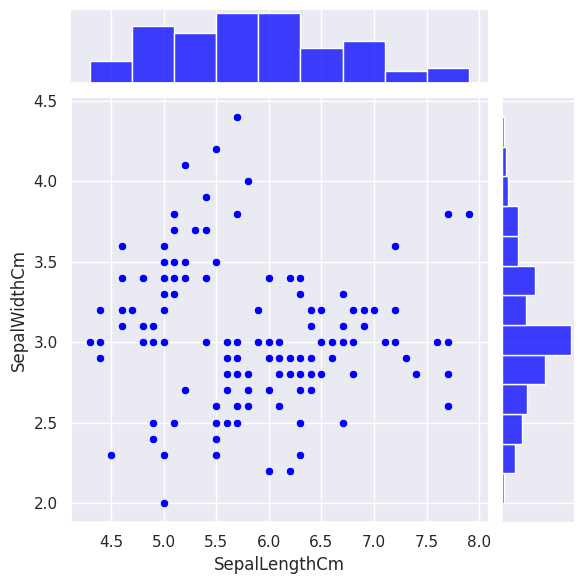

```python
#Exercise solution
fig=sns.jointplot(x='SepalLengthCm', y='SepalWidthCm', data=iris, color='blue')
plt.show()
#Note: I wouldn't mix the species in this analysis.
```

8. Write a Python program to create a joinplot using "hexbin" to describe individual distributions on the same plot between Sepal length and Sepal width.

Note: The bivariate analogue of a histogram is known as a "hexbin" plot, because it shows the counts of observations that fall within hexagonal bins. This plot works best with relatively large datasets. It's available through the matplotlib plt.hexbin function and as a style in jointplot(). It looks best with a white background.

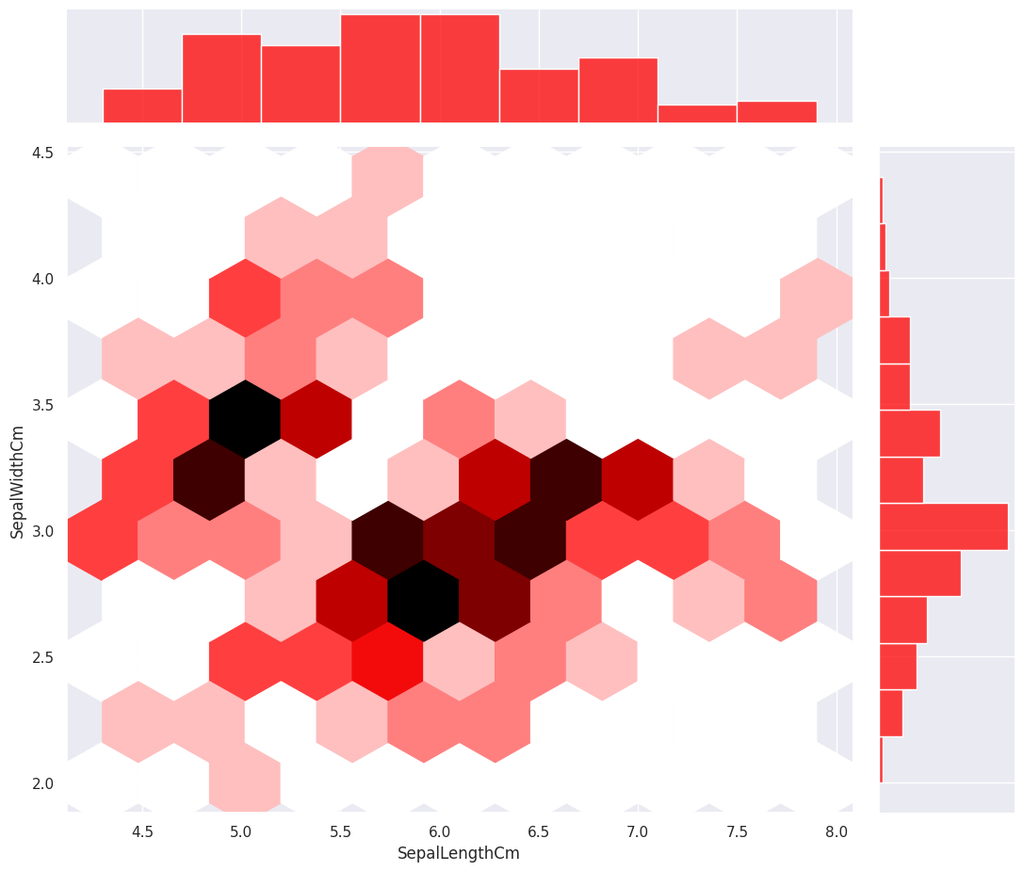

```python
#Exercise solution
axis=sns.jointplot(x='SepalLengthCm', y='SepalWidthCm', kind="hex", color="red", data=iris)
fig=plt.gcf()
fig.set_size_inches(12,10)
plt.show()
#Note: I wouldn't mix the species in this analysis.
```

9. Write a Python program to create a joinplot using "kde" to describe individual distributions on the same plot between Sepal length and Sepal width.

Note: The kernel density estimation (kde) procedure visualize a bivariate distribution. In seaborn, this kind of plot is shown with a contour plot and is available as a style in jointplot().

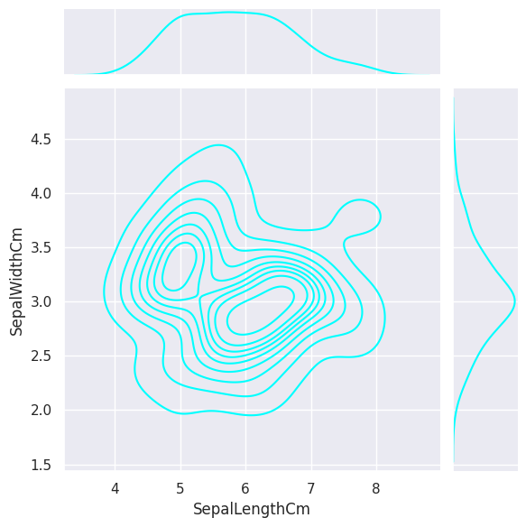

```python
#exercise solution
fig=sns.jointplot(x='SepalLengthCm', y='SepalWidthCm', kind="kde", color='cyan', data=iris)
plt.show()
#Note: I wouldn't mix the species in this analysis.
```

10. Write a Python program to create a joinplot and add regression and kernel density fits using "reg" to describe individual distributions on the same plot between Sepal length and Sepal width.

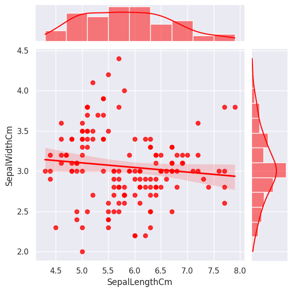

```python
#Exercise solution
fig=sns.jointplot(x='SepalLengthCm', y='SepalWidthCm', kind="reg", color='red', data=iris)
plt.show()
#Note: I wouldn't mix the species in this analysis.
```

13. Write a Python program to create a pairplot of the iris data set and check which flower species seems to be the most separable.

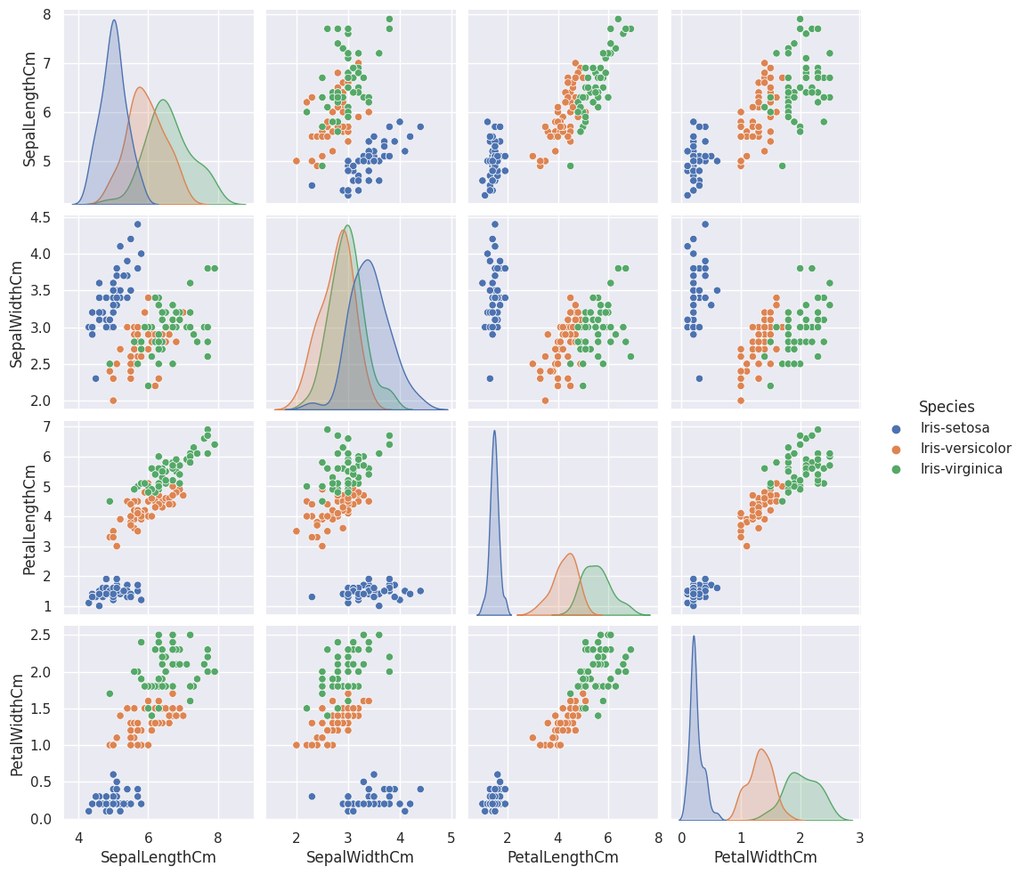

```python
sns.pairplot(iris,hue='Species')
plt.show()
```